# Prediction

November 2, 2015

## The central dogma of prediction

[figure not shown]

## Other words for prediction

- Prediction -> statisticians
- Statistical learning -> statisticians
- Machine learning -> computer scientists
- Forecasting -> atmospheric scientists/bankers
- Artificial intelligence -> the popular press

## Machine learning is everywhere

[figure not shown]

https://www.google.com/selfdrivingcar/

## Machine learning can make you rich

[figure not shown]

http://venturebeat.com/2015/06/17/twitter-acquires-machine-learning-startup-whetlab-will-kill-the-service-on-july-15/

## Who predicts?

- Local governments -> pension payments
- Google -> whether you will click on an ad
- Amazon -> what movies you will watch
- Insurance companies -> what your risk of death is
- Johns Hopkins -> who will succeed in their programs

## Why predict? Glory!

[figure not shown]

http://www.zimbio.com/photos/Chris+Volinsky

## Why predict? For sport!

[figure not shown]

http://www.kaggle.com/

## Why predict? To save lives!

[figure not shown]

http://www.oncotypedx.com/en-US/Home

## A useful (if a bit advanced) book

[figure not shown]

[The elements of statistical learning](http://statweb.stanford.edu/~tibs/ElemStatLearn/)

## A useful package

[figure not shown]

http://caret.r-forge.r-project.org/

## Components of a predictor

question -> input data -> features -> algorithm -> parameters -> evaluation

## SPAM Example

question -> input data -> features -> algorithm -> parameters -> evaluation

**Start with a general question**

Can I automatically detect emails that are SPAM that are not?

**Make it concrete**

Can I use quantitative characteristics of the emails to classify them as SPAM/HAM?

## SPAM Example

question -> input data -> features -> algorithm -> parameters -> evaluation

[figure not shown]

http://rss.acs.unt.edu/Rdoc/library/kernlab/html/spam.html

## SPAM Example

question -> input data -> features -> algorithm -> parameters -> evaluation

**Dear Jeff,**

Can you send me your address so I can send you the invitation?

Thanks,

Ben

## Spam example

question -> input data -> features -> algorithm -> parameters -> evaluation

Dear Jeff,

Can you send me your address so I can send you the invitation?

Thanks,

Ben

Frequency of you \(= 2/17 = 0.118\)

## Spam example

question -> input data -> features -> algorithm -> parameters -> evaluation

```r
library(kernlab)
data(spam)
head(spam)
```

```
##   make address  all num3d  our over remove internet order mail receive
## 1 0.00    0.64 0.64     0 0.32 0.00   0.00     0.00  0.00 0.00    0.00
## 2 0.21    0.28 0.50     0 0.14 0.28   0.21     0.07  0.00 0.94    0.21
## 3 0.06    0.00 0.71     0 1.23 0.19   0.19     0.12  0.64 0.25    0.38
## 4 0.00    0.00 0.00     0 0.63 0.00   0.31     0.63  0.31 0.63    0.31
## 5 0.00    0.00 0.00     0 0.63 0.00   0.31     0.63  0.31 0.63    0.31
## 6 0.00    0.00 0.00     0 1.85 0.00   0.00     1.85  0.00 0.00    0.00
##   will people report addresses free business email  you credit your font
## 1 0.64   0.00   0.00      0.00 0.32     0.00  1.29 1.93   0.00 0.96    0
## 2 0.79   0.65   0.21      0.14 0.14     0.07  0.28 3.47   0.00 1.59    0
## 3 0.45   0.12   0.00      1.75 0.06     0.06  1.03 1.36   0.32 0.51    0
## 4 0.31   0.31   0.00      0.00 0.31     0.00  0.00 3.18   0.00 0.31    0
## 5 0.31   0.31   0.00      0.00 0.31     0.00  0.00 3.18   0.00 0.31    0
## 6 0.00   0.00   0.00      0.00 0.00     0.00  0.00 0.00   0.00 0.00    0
##   num000 money hp hpl george num650 lab labs telnet num857 data num415
```

[output cut: 34 more lines]

## Spam example

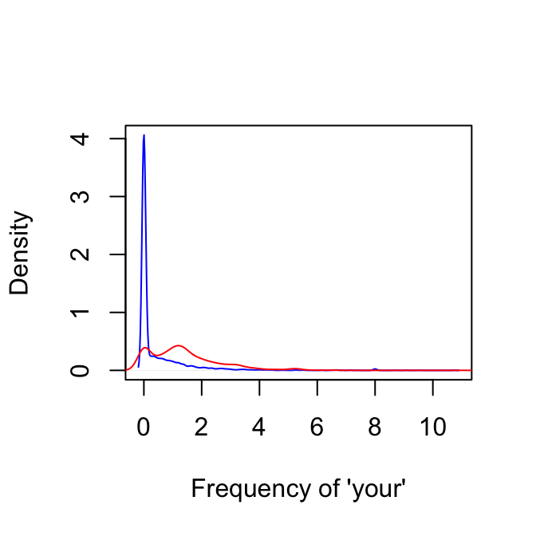

```r
plot(density(spam$your[spam$type=="nonspam"]),
     col="blue",main="",xlab="Frequency of 'your'")
lines(density(spam$your[spam$type=="spam"]),col="red")
```

## SPAM Example

question -> input data -> features -> algorithm -> parameters -> evaluation

**Our algorithm**

- Find a value \(C\).
- **frequency of 'your' \(>\) C** predict "spam"

## SPAM Example

question -> input data -> features -> algorithm -> parameters -> evaluation

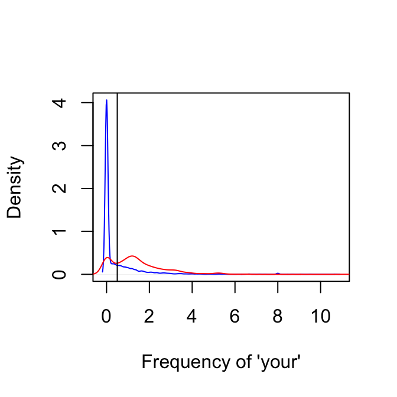

```r
plot(density(spam$your[spam$type=="nonspam"]),
     col="blue",main="",xlab="Frequency of 'your'")
lines(density(spam$your[spam$type=="spam"]),col="red")
abline(v=0.5,col="black")
```

## SPAM Example

question -> input data -> features -> algorithm -> parameters -> evaluation

```r
prediction <- ifelse(spam$your > 0.5,"spam","nonspam")
table(prediction,spam$type)/length(spam$type)
```

```
##
## prediction   nonspam      spam
##    nonspam 0.4590306 0.1017170
##    spam    0.1469246 0.2923278
```

Accuracy \(\approx 0.459 + 0.292 = 0.751\)

## An important point

*The combination of some data and an aching desire for an answer does not ensure that a reasonable answer can be extracted from a given body of data.*

- John Tukey

## Garbage in = Garbage out

question -> input data -> features -> algorithm -> parameters -> evaluation

1. May be easy (movie ratings -> new movie ratings)
2. May be harder (gene expression data -> disease)
3. Depends on what is a "good prediction".
4. Often [more data > better models](http://www.youtube.com/watch?v=yvDCzhbjYWs)
5. The most important step!

## Features matter!

question -> input data -> features -> algorithm -> parameters -> evaluation

**Properties of good features**

- Lead to data compression
- Retain relevant information
- Are created based on expert application knowledge

**Common mistakes**

- Trying to automate feature selection
- Not paying attention to data-specific quirks
- Throwing away information unnecessarily

## Automating feature selection

question -> input data -> features -> algorithm -> parameters -> evaluation

[figure not shown]

http://arxiv.org/pdf/1112.6209v5.pdf

## Issues to consider

[figure not shown]

http://strata.oreilly.com/2013/09/gaining-access-to-the-best-machine-learning-methods.html

## Prediction is about accuracy tradeoffs

- Interpretability versus accuracy
- Speed versus accuracy
- Simplicity versus accuracy
- Scalability versus accuracy

## Interpretability matters

[figure not shown]

http://www.cs.cornell.edu/~chenhao/pub/mldg-0815.pdf

## Scalability matters

[figure not shown]

http://www.techdirt.com/blog/innovation/articles/20120409/03412518422/

http://techblog.netflix.com/2012/04/netflix-recommendations-beyond-5-stars.html

## In sample versus out of sample

**In Sample Error**: The error rate you get on the same data set you used to build your predictor. Sometimes called resubstitution error.

**Out of Sample Error**: The error rate you get on a new data set. Sometimes called generalization error.

**Key ideas**

1. Out of sample error is what you care about
2. In sample error \(<\) out of sample error
3. The reason is overfitting
   - Matching your algorithm to the data you have

## In sample versus out of sample errors

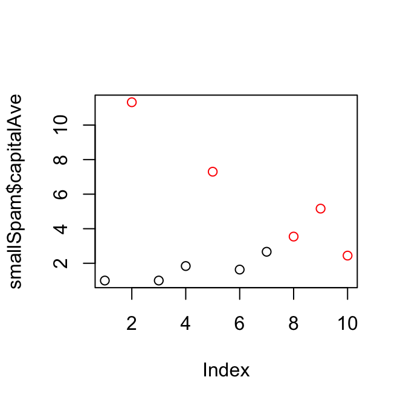

```r
library(kernlab); data(spam); set.seed(333)
smallSpam <- spam[sample(dim(spam)[1],size=10),]
spamLabel <- (smallSpam$type=="spam")*1 + 1
plot(smallSpam$capitalAve,col=spamLabel)
```

## Prediction rule 1

- capitalAve \(>\) 2.7 = "spam"
- capitalAve \(<\) 2.40 = "nonspam"
- capitalAve between 2.40 and 2.45 = "spam"
- capitalAve between 2.45 and 2.7 = "nonspam"

## Apply Rule 1 to smallSpam

```r
rule1 <- function(x){
  prediction <- rep(NA,length(x))
  prediction[x > 2.7] <- "spam"
  prediction[x < 2.40] <- "nonspam"
  prediction[(x >= 2.40 & x <= 2.45)] <- "spam"
  prediction[(x > 2.45 & x <= 2.70)] <- "nonspam"
  return(prediction)
}
table(rule1(smallSpam$capitalAve),smallSpam$type)
```

```
##
##           nonspam spam
##   nonspam       5    0
##   spam          0    5
```

## Apply Rule 2 to smallSpam

```r
rule2 <- function(x){
  prediction <- rep(NA,length(x))
  prediction[x > 2.8] <- "spam"
  prediction[x <= 2.8] <- "nonspam"
  return(prediction)
}
table(rule2(smallSpam$capitalAve),smallSpam$type)
```

```
##
##           nonspam spam
##   nonspam       5    1
##   spam          0    4
```

## Apply to complete spam data

```r
table(rule1(spam$capitalAve),spam$type)
```

```
##
##           nonspam spam
##   nonspam    2141  588
##   spam        647 1225
```

```r
table(rule2(spam$capitalAve),spam$type)
```

```
##
##           nonspam spam
##   nonspam    2224  642
##   spam        564 1171
```

## Apply to complete spam data

```r
mean(rule1(spam$capitalAve)==spam$type)
```

```
## [1] 0.7315801
```

```r
mean(rule2(spam$capitalAve)==spam$type)
```

```
## [1] 0.7378831
```

## Look at accuracy

```r
sum(rule1(spam$capitalAve)==spam$type)
```

```
## [1] 3366
```

```r
sum(rule2(spam$capitalAve)==spam$type)
```

```
## [1] 3395
```

## Basic terms

In general, **Positive** = identified and **negative** = rejected. Therefore:

**True positive** = correctly identified

**False positive** = incorrectly identified

**True negative** = correctly rejected

**False negative** = incorrectly rejected

*Medical testing example*:

**True positive** = Sick people correctly diagnosed as sick

**False positive**= Healthy people incorrectly identified as sick

**True negative** = Healthy people correctly identified as healthy

**False negative** = Sick people incorrectly identified as healthy.

http://en.wikipedia.org/wiki/Sensitivity_and_specificity

## Define your error rate

[figure not shown]

http://en.wikipedia.org/wiki/Sensitivity_and_specificity

## Key quantities

[figure not shown]

## Key quantities as fractions

[figure not shown]

## Screening tests

[figure not shown]

## General population

[figure not shown]

## General population as fractions

[figure not shown]

## At risk subpopulation

[figure not shown]

## At risk subpopulation as fraction

[figure not shown]

## Key public health issue

[figure not shown]

## Key public health issue

[figure not shown]

## For continuous data

**Mean squared error (MSE)**:

\[\frac{1}{n} \sum_{i=1}^n (Prediction_i - Truth_i)^2\]

**Root mean squared error (RMSE)**:

\[\sqrt{\frac{1}{n} \sum_{i=1}^n(Prediction_i - Truth_i)^2}\]

## Common error measures

1. Mean squared error (or root mean squared error)
   - Continuous data, sensitive to outliers
2. Median absolute deviation
   - Continuous data, often more robust
3. Sensitivity (recall)
   - If you want few missed positives
4. Specificity
   - If you want few negatives called positives
5. Accuracy
   - Weights false positives/negatives equally
6. Concordance
   - One example is kappa
7. Predictive value of a positive (precision)
   - When you are screeing and prevelance is low

## ROC curves

[figure not shown]

http://en.wikipedia.org/wiki/Receiver_operating_characteristic

## ROC Curve example

[figure not shown]

http://en.wikipedia.org/wiki/Receiver_operating_characteristic

## Area under the curve

[figure not shown]

- AUC = 0.5: random guessing
- AUC = 1: perfect classifer
- In general AUC of above 0.8 considered "good"

http://en.wikipedia.org/wiki/Receiver_operating_characteristic

## Prediction and association

[figure not shown]

## What is good?

[figure not shown]

http://en.wikipedia.org/wiki/Receiver_operating_characteristic

## Study design

[figure not shown]

http://www2.research.att.com/~volinsky/papers/ASAStatComp.pdf

## Key idea

1. Accuracy on the training set (resubstitution accuracy) is optimistic
2. A better estimate comes from an independent set (test set accuracy)
3. But we can't use the test set when building the model or it becomes part of the training set
4. So we estimate the test set accuracy with the training set.

## Cross-validation

*Approach*:

1. Use the training set
2. Split it into training/test sets
3. Build a model on the training set
4. Evaluate on the test set
5. Repeat and average the estimated errors

*Used for*:

1. Picking variables to include in a model
2. Picking the type of prediction function to use
3. Picking the parameters in the prediction function
4. Comparing different predictors

## Random subsampling

[figure not shown]

## K-fold

[figure not shown]

## Leave one out

[figure not shown]

## Considerations

- For time series data data must be used in "chunks"
- For k-fold cross validation
  - Larger k = less bias, more variance
  - Smaller k = more bias, less variance
- Random sampling must be done *without replacement*
- Random sampling with replacement is the *bootstrap*
  - Underestimates of the error
  - Can be corrected, but it is complicated ([0.632 Bootstrap](http://www.jstor.org/discover/10.2307/2965703?uid=2&uid=4&sid=21103054448997))
- If you cross-validate to pick predictors estimate you must estimate errors on independent data.

## A succcessful predictor

[figure not shown]

fivethirtyeight.com

## Polling data

[figure not shown]

http://www.gallup.com/

## Weighting the data

[figure not shown]

http://www.fivethirtyeight.com/2010/06/pollster-ratings-v40-methodology.html

## Key idea

To predict X use data related to X

## Key idea

To predict player performance use data about player performance

[figure not shown]

## Key idea

To predict movie preferences use data about movie preferences

[figure not shown]

## Not a hard rule

To predict flu outbreaks use Google searches

[figure not shown]

http://www.google.org/flutrends/

## But be careful

[figure not shown]

http://gking.harvard.edu/files/gking/files/0314policyforumff.pdf

## Looser connection = harder prediction

[figure not shown]

## Data properties matter

[figure not shown]

## Unrelated data is the most common mistake

[figure not shown]

http://www.nejm.org/doi/full/10.1056/NEJMon1211064